# matplotlib.patches.Polygon

**class*matplotlib.patches.Polygon(*xy*, *, *closed=True*, **kwargs)[[source]](https://github.com/matplotlib/matplotlib/blob/v3.9.2/lib/matplotlib/patches.py#L1117-L1213)**

Bases: `Patch`

A general polygon patch.

**Parameters:**

**xy**(N, 2) array**

**closed**bool, default: True**

Whether the polygon is closed (i.e., has identical start and end points).

**kwargs**

[output not shown]

**get_closed()[[source]](https://github.com/matplotlib/matplotlib/blob/v3.9.2/lib/matplotlib/patches.py#L1149-L1151)**

Return whether the polygon is closed.

**get_path()[[source]](https://github.com/matplotlib/matplotlib/blob/v3.9.2/lib/matplotlib/patches.py#L1145-L1147)**

Get the `Path` of the polygon.

**get_xy()[[source]](https://github.com/matplotlib/matplotlib/blob/v3.9.2/lib/matplotlib/patches.py#L1168-L1177)**

Get the vertices of the path.

**Returns:**

**(N, 2) array**

The coordinates of the vertices.

**set(*, *agg_filter=<UNSET>*, *alpha=<UNSET>*, *animated=<UNSET>*, *antialiased=<UNSET>*, *capstyle=<UNSET>*, *clip_box=<UNSET>*, *clip_on=<UNSET>*, *clip_path=<UNSET>*, *closed=<UNSET>*, *color=<UNSET>*, *edgecolor=<UNSET>*, *facecolor=<UNSET>*, *fill=<UNSET>*, *gid=<UNSET>*, *hatch=<UNSET>*, *in_layout=<UNSET>*, *joinstyle=<UNSET>*, *label=<UNSET>*, *linestyle=<UNSET>*, *linewidth=<UNSET>*, *mouseover=<UNSET>*, *path_effects=<UNSET>*, *picker=<UNSET>*, *rasterized=<UNSET>*, *sketch_params=<UNSET>*, *snap=<UNSET>*, *transform=<UNSET>*, *url=<UNSET>*, *visible=<UNSET>*, *xy=<UNSET>*, *zorder=<UNSET>*)[[source]](https://github.com/matplotlib/matplotlib/blob/v3.9.2/lib/matplotlib/artist.py#L147-L147)**

Set multiple properties at once.

Supported properties are

| Property | Description |
| --- | --- |
| `agg_filter` | a filter function, which takes a (m, n, 3) float array and a dpi value, and returns a (m, n, 3) array and two offsets from the bottom left corner of the image |
| `alpha` | scalar or None |
| `animated` | bool |
| `antialiased` or aa | bool or None |
| `capstyle` | `CapStyle` or {'butt', 'projecting', 'round'} |
| `clip_box` | `BboxBase` or None |
| `clip_on` | bool |
| `clip_path` | Patch or (Path, Transform) or None |
| `closed` | bool |
| `color` | [color](https://matplotlib.org/stable/users/explain/colors/colors.html#colors-def) |
| `edgecolor` or ec | [color](https://matplotlib.org/stable/users/explain/colors/colors.html#colors-def) or None |
| `facecolor` or fc | [color](https://matplotlib.org/stable/users/explain/colors/colors.html#colors-def) or None |
| `figure` | `Figure` |
| `fill` | bool |
| `gid` | str |
| `hatch` | {'/', '\', '\|', '-', '+', 'x', 'o', 'O', '.', '*'} |
| `in_layout` | bool |
| `joinstyle` | `JoinStyle` or {'miter', 'round', 'bevel'} |
| `label` | object |
| `linestyle` or ls | {'-', '--', '-.', ':', '', (offset, on-off-seq), ...} |
| `linewidth` or lw | float or None |
| `mouseover` | bool |
| `path_effects` | list of `AbstractPathEffect` |
| `picker` | None or bool or float or callable |
| `rasterized` | bool |
| `sketch_params` | (scale: float, length: float, randomness: float) |
| `snap` | bool or None |
| `transform` | `Transform` |
| `url` | str |
| `visible` | bool |
| `xy` | (N, 2) array-like |
| `zorder` | float |

**set_closed(*closed*)[[source]](https://github.com/matplotlib/matplotlib/blob/v3.9.2/lib/matplotlib/patches.py#L1153-L1166)**

Set whether the polygon is closed.

**Parameters:**

**closed**bool**

True if the polygon is closed

**set_xy(*xy*)[[source]](https://github.com/matplotlib/matplotlib/blob/v3.9.2/lib/matplotlib/patches.py#L1179-L1210)**

Set the vertices of the polygon.

**Parameters:**

**xy**(N, 2) array-like**

The coordinates of the vertices.

#### Notes

Unlike `Path`, we do not ignore the last input vertex. If the polygon is meant to be closed, and the last point of the polygon is not equal to the first, we assume that the user has not explicitly passed a `CLOSEPOLY` vertex, and add it ourselves.

**property*xy**

The vertices of the path as a (N, 2) array.

## Examples using `matplotlib.patches.Polygon`

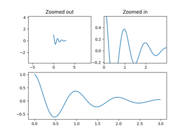

[Controlling view limits using margins and sticky_edges](https://matplotlib.org/stable/gallery/subplots_axes_and_figures/axes_margins.html#sphx-glr-gallery-subplots-axes-and-figures-axes-margins-py)

Controlling view limits using margins and sticky_edges

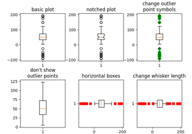

[Boxplots](https://matplotlib.org/stable/gallery/statistics/boxplot_demo.html#sphx-glr-gallery-statistics-boxplot-demo-py)

Boxplots

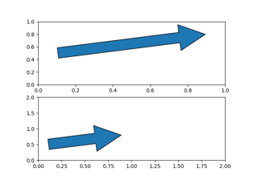

[Arrow guide](https://matplotlib.org/stable/gallery/shapes_and_collections/arrow_guide.html#sphx-glr-gallery-shapes-and-collections-arrow-guide-py)

Arrow guide

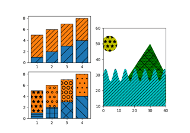

[Hatch demo](https://matplotlib.org/stable/gallery/shapes_and_collections/hatch_demo.html#sphx-glr-gallery-shapes-and-collections-hatch-demo-py)

Hatch demo

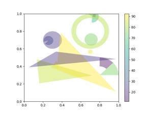

[Circles, Wedges and Polygons](https://matplotlib.org/stable/gallery/shapes_and_collections/patch_collection.html#sphx-glr-gallery-shapes-and-collections-patch-collection-py)

Circles, Wedges and Polygons

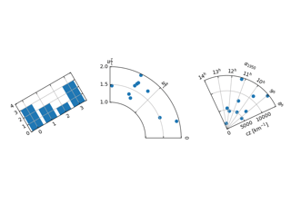

[floating_axes features](https://matplotlib.org/stable/gallery/axisartist/demo_floating_axes.html#sphx-glr-gallery-axisartist-demo-floating-axes-py)

floating_axes features

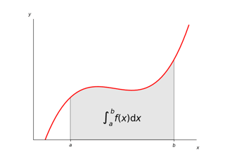

[Integral as the area under a curve](https://matplotlib.org/stable/gallery/showcase/integral.html#sphx-glr-gallery-showcase-integral-py)

Integral as the area under a curve

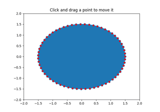

[Poly Editor](https://matplotlib.org/stable/gallery/event_handling/poly_editor.html#sphx-glr-gallery-event-handling-poly-editor-py)

Poly Editor

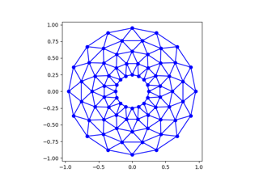

[Trifinder Event Demo](https://matplotlib.org/stable/gallery/event_handling/trifinder_event_demo.html#sphx-glr-gallery-event-handling-trifinder-event-demo-py)

Trifinder Event Demo

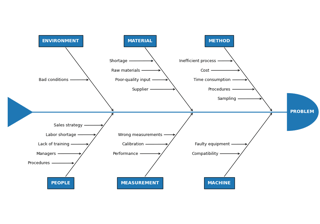

[Ishikawa Diagram](https://matplotlib.org/stable/gallery/specialty_plots/ishikawa_diagram.html#sphx-glr-gallery-specialty-plots-ishikawa-diagram-py)

Ishikawa Diagram

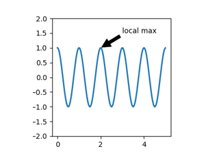

[Annotations](https://matplotlib.org/stable/users/explain/text/annotations.html#sphx-glr-users-explain-text-annotations-py)

Annotations